# Supplementary material of the manuscript

Extended methods (A1–A11, 23 equations), complementary results (B1–B4), tables S1–S9 and figures S1–S9 (version 10), with the figures regenerated at render time

Published

September 14, 2026

Home Methods REM GRD Manuscript Supplement Corpus

**7**Supplementary figures regenerated by this page in 24 s (plus S1 and S6, inherited)

**23**Numbered equations of the extended methods (STIX images from equations_lancet.py)

**16**Supplementary table parts (S1 to S9)

**15**Supplementary references

The supplement opens with the extended methods (sections A1 to A11) and continues with the complementary results, the tables and the figures, in the same order as the submitted document (`supplement_en.docx`). The text and tables come from `docs/lancet/data/contenido_v10.json`; the equations are the images composed with the STIX family that the document prints, at a single type size. Figures S2–S5 and S7–S9 are rebuilt at every render by `docs/lancet/figuras_suplementarias.py` from `docs/lancet/data/`; figures S1 (data flow) and S6 (territorial maps) are plates inherited from revision 09. In figure S7 and in figure 4d of the article, the commune comparison uses `communes_public.csv`, an extract without identifiers in which cells with 1 to 4 records are masked variable by variable, so that the points shown coincide with those of the manuscript; the sensitivity to the count threshold (S7d) is read precomputed on the complete commune file, which is not published.

Layout check of the plates generated in this render (text outside the canvas and overlaps between labels must be zero)

| Figure | Language | Width (mm) | Height (mm) | Font sizes (pt) | Off-canvas texts | Overlaps |
| --- | --- | --- | --- | --- | --- | --- |
| Figure S2 | en | 175.0 | 172.0 | 5.8–11.0 | 0 | 0 |
| Figure S3 | en | 175.0 | 165.0 | 6.2–11.0 | 0 | 0 |
| Figure S4 | en | 175.0 | 178.0 | 6.0–11.0 | 0 | 0 |
| Figure S5 | en | 175.0 | 150.0 | 5.8–11.0 | 0 | 0 |
| Figure S7 | en | 175.0 | 165.0 | 6.4–11.0 | 0 | 0 |
| Figure S8 | en | 175.0 | 95.0 | 6.0–11.0 | 0 | 0 |
| Figure S9 | en | 175.0 | 95.0 | 6.2–11.0 | 0 | 0 |
| Figure S2 | es | 175.0 | 172.0 | 5.8–11.0 | 0 | 0 |
| Figure S3 | es | 175.0 | 165.0 | 6.2–11.0 | 0 | 0 |
| Figure S4 | es | 175.0 | 178.0 | 6.0–11.0 | 0 | 0 |
| Figure S5 | es | 175.0 | 150.0 | 5.8–11.0 | 0 | 0 |
| Figure S7 | es | 175.0 | 165.0 | 6.4–11.0 | 0 | 0 |
| Figure S8 | es | 175.0 | 95.0 | 6.0–11.0 | 0 | 0 |
| Figure S9 | es | 175.0 | 95.0 | 6.2–11.0 | 0 | 0 |

Amaru Agüero Jiménez; Patricia Soto Icaza

Centro de Investigación en Complejidad Social, Facultad de Gobierno, Universidad del Desarrollo

Correspondence to: Patricia Soto Icaza, patriciasoto@udd.cl (affiliation above). [Postal address and telephone to be completed.]

## Contents

A. Extended methods (A1–A11) ··· 2 B. Complementary results (B1–B4) ··· 10 Tables S1–S9 ··· 13 Figures S1–S9 ··· 24 Supplementary references ··· 33

### Scope and reading guide

This supplement provides the scientific definitions, estimators and selected complementary results for the bilingual article. Tables and figure labels have the same numbering in both languages. GRD denotes hospital diagnosis-related groups; REM denotes Monthly Statistical Summaries; PIE denotes the School Integration Programme; NANEAS denotes children and adolescents with special health-care needs. All displayed intervals are 95% unless stated otherwise.

## A. Extended methods

### A1. Study design, sources and observation units

This is a repeated cross-sectional study of administrative recording across Chilean health and education systems, with external population-survey context. The hospital core comprises public-hospital diagnosis-related group (GRD) episodes in 2019–2024. Complementary health-service series come from Monthly Statistical Summaries (REM), with available periods determined by the module and diagnostic era. The School Integration Programme (PIE) provides educational administrative triangulation in 2019–2025. The National Disability and Dependency Survey (ENDIDE) 2022 and the National Quality of Life and Health Survey (ENCAVI) 2023–2024 describe different survey populations and questions. The study estimates recorded activity, follow-up stocks and administrative indicators; it does not estimate the population prevalence or incidence of clinically validated autism.<sup>1,2</sup>

GRD observations are episodes, REM observations are establishment–month–code records or establishment-specific semester cuts, and educational observations are the published school-registration totals. These sources were not linked at the individual level. Similar trends therefore cannot establish that the same people progressed through screening, referral, entry and follow-up. The availability of a record in one system does not imply inclusion in another. Hospital episode identifiers support within-year person counts only under the restrictions below. Survey design, educational harmonisation and territorial methods are described separately because their observation units, denominators and coverage differ.

Figure S1 summarises independent processing streams rather than a participant cohort. The six GRD files contained 5 808 535 activity episodes. Applying the eligible-code rule retained 25 323 episodes: 1 617 with an eligible principal diagnosis and 23 706 with eligible diagnoses exclusively in secondary positions. Of 327 episodes mentioning Rett, 297 had no other eligible code and were excluded; 30 remained eligible. The 297 Rett-only episodes remained in the overall hospital activity denominator. Hospital comparisons use the numerator and denominator for the same year, hospital panel and activity modality; valid identifiers support person counts only within each year. A05 (REM mental-health entry module) aggregates known monthly totals of code 05990022 as an annual flow, while P2 (REM child/adolescent special-health-needs follow-up module) selects P2500500 at December as a stock. Stable A05 membership requires at least one selected-code row in every year of 2021–2025; stable P2 membership requires a December row in every year of 2019–2025. Missing cells, absent rows and true zero values retain distinct meanings. The P2 age-universe change in 2021 is treated as a definition break, with same-era and under-10 analyses. PIE categories are harmonised within documented source eras. ENDIDE and ENCAVI use their eligible age and valid-response domains, weights, strata and primary sampling units; they provide external population context and are not clinical validation of administrative records.

### A2. Hospital eligibility, position, activity and identifiers

F84, pervasive developmental disorders, is a category of the disorders of psychological development block (F80–F89) of chapter V of the tenth revision of the International Classification of Diseases, mental and behavioural disorders. The selected hospital definition comprises the exact codes F84 at category level, F84.0 childhood autism, F84.1 atypical autism, F84.3 other childhood disintegrative disorder, F84.4 overactive disorder associated with intellectual disability and stereotyped movements, F84.5 Asperger syndrome, F84.8 other pervasive developmental disorders and F84.9 pervasive developmental disorder, unspecified, in any of 35 diagnostic positions. F84.2 is Rett syndrome. Codes were standardised to uppercase with punctuation and spaces removed before exact matching. F84.2, Rett syndrome, does not confer eligibility. However, an episode with another eligible diagnosis remains included when F84.2 coexists. This is removal of Rett as an eligible code, not exclusion of everyone whose episode mentions Rett. F84.0 alone and the broader F84 family including F84.2 are separate definition sensitivities; neither replaces the selected numerator.

Principal diagnosis means an eligible code in the first diagnostic position, whether or not another eligible code appears secondarily. Exclusively secondary diagnosis means eligibility in positions 2–35 with no eligible code in the first position. The principal and exclusively secondary categories are mutually exclusive and sum to the any-position count. Episodes with principal Rett and an eligible secondary diagnosis contribute to the any-position and secondary-only categories, but not to the selected principal category. In 2024, 94 episodes mentioned Rett: 87 had no other eligible code and were excluded; seven remained eligible through a coexisting code.

The primary denominator is all GRD episodes in the corresponding hospital panel and year. Hospitalisation and major ambulatory surgery are analysed separately with their own modality denominators. A residual activity category occurs in 2019 but has no records in 2020–2024; its absence is not a zero-valued rate. Coding depth is the number of nonempty diagnostic fields per episode. The coding-stratum comparison divides eligible episodes by all episodes in the same stratum; the inset presents descriptive mean depth. Within-year person counts use valid identifiers, excluding missing or explicitly uninformative identifiers. Identifier encoding changes between 2020 and 2021, with no shared eligible identifiers across that boundary, and the variable name changes in 2024. Counts were not summed across years as unique people and do not define a longitudinal cohort.

For the existing hospital clinical-context analysis, diagnoses other than F84 were reduced to three-character International Classification of Diseases, tenth revision (ICD-10) categories. Within each eligible episode, duplicate occurrences of the same category were removed separately for principal, secondary and any-position tabulations. Principal diagnoses among secondary-only eligible episodes describe the recorded main diagnosis at that contact. Chapter summaries count an episode once per chapter, even if several codes from that chapter occur. Chapters can overlap within an episode. We selected the ten most frequent principal categories and chapters in 2024 and retained the same categories in the 2019 comparison; no significance test or new risk model selected them. Denominators were independently checked against the hospital core in every year. Clinical descriptions refer to administrative coding and are not a validation of diagnoses or an estimate of comorbidity in autistic residents.

### A3. REM definitions, diagnostic eras, flows and stocks

A05 strict-autism entries use code 05990022 from 2021 and are annual sums of the reported both-sex total. The broader post-2021 pervasive-developmental-disorder family includes autism, Asperger syndrome, childhood disintegrative disorder and unspecified pervasive developmental disorder; the Rett entry category, 05990024, is excluded from the selected family sensitivity. These broader totals are not labelled strict autism. Broad A05 code 06902600 in 2019–2020 cannot be separated into the later strict categories and is not joined to the strict-autism series. A05 discharges are separate flows and do not imply that an identified entrant subsequently left care.

P2 code P2500500 records autism within the population of children and adolescents with special health-care needs under follow-up. Full age-column inspection identified an expansion in its reporting universe: the 2019–2020 layout covers children younger than 10 years, whereas the 2021–2025 layout includes ages 10–14 and 15–19 years, extending the universe to younger than 20 years. The reported total and the unchanged code therefore do not form an age-comparable 2019–2025 series. Figures separate the two eras; the main post-expansion comparison is 2021–2025. December is the principal cut and June is shown separately. Counts at different cuts are never summed as unique people.

A bounded common-age P2 sensitivity sums known age–sex cells for children younger than 10 years, using the same age-by-sex cells in every December file. The sums equal the reported total in 2019–2020. After expansion they exclude the newly represented adolescent groups; rows with all those age cells empty remain missing rather than being assigned zero. The sensitivity reports both the known-age sums and their missingness. P6 (REM mental-health follow-up module) primary-care and specialty stocks similarly remain distinct: broad codes P6223000 and P6223380 in 2019–2020 are separated from strict-autism codes P6241010 and P6241060 in 2021–2025. A28 (REM rehabilitation module) primary-care and hospital rehabilitation entries, codes 29101629 and 29101651, are annual flows in 2023–2025. They are not stocks or linked transitions.

### A4. Stable panels, missingness and 2025 availability

The hospital stable panel contains the 65 hospital identifiers present in every year of 2019–2022; all 65 also contribute in 2023 and 2024, making this set identical to the six-year intersection. The annual observed network expands to 68 hospitals in 2023 and 72 in 2024. A05 stable membership requires at least one strict-code row in every year 2021–2025, yielding 258 establishments. The original P2 December intersection across 2019–2025 contains 193 establishments; it is retained as a fixed-establishment sensitivity but does not correct the 2021 age expansion. Restricting the membership window to the comparable 2021–2025 era yields 433 establishments, reported as an additional bounded sensitivity.

Annual row presence, a known value, a recorded zero and complete monthly reporting are different properties. Known numeric totals are summed; empty cells remain missing, and a group containing no known total is missing. Explicit zeros are retained. An absent establishment-month cannot distinguish inactivity, an omitted zero or nonreporting and is not imputed as zero. National A05 strict-code records span all 12 months each year, yet only 2, 5, 14, 29 and 55 establishments respectively have a row in every month of 2021–2025. These figures describe stored-row presence, not a reporting-compliance rate. One A05 total cell is empty in 2024 and one in 2025.

The selected A05, P6 and A28 code layouts are compatible between 2024 and 2025, and the earlier P2 age change is documented separately. National availability does not prove that all eligible establishments submitted complete data. In particular, A05 annual reporters fall from 1 070 in 2024 to 952 in 2025 despite increasing totals. Neither a stable panel nor an establishment offset identifies the fraction of growth attributable to expanding coverage, activity, diagnostic recognition or recording practices.

### A5. Denominators and population compatibility

The central hospital indicator is activity-denominated: its denominator is observed GRD episodes, not residents, beneficiaries or hospitals. Population-denominated age and sex indicators instead use National Statistics Institute (INE) resident-population projections, base 2017, at 30 June, matched by year and age–sex group. Their numerators are public-network records. The population actually covered by the reporting network is not established, so these indicators are not autism prevalence or risk within a known covered population. A05 is located by establishment, whereas GRD territorial analysis uses recorded residence. Dividing establishment-based REM counts by residents does not ensure that numerator and denominator refer to the same people.<sup>3</sup>

Beneficiary totals, primary-care enrolment, resident populations and numbers of reporting establishments represent distinct reference quantities. They are not interchangeable denominators or components of a mutually exclusive partition of the Chilean population. Denominator sensitivities retain their original timing and geographic definition and are interpreted within their own estimands. Ratios per establishment describe recorded volume per reporting site, not individual risk; a hospital activity denominator describes the share of episodes with an eligible code, not the fraction of all residents who have autism.

### A6. Rates, standardisation, uncertainty, sex ratios and indices

Unstandardised indicators are 100 000 times the observed count divided by the corresponding positive denominator. Exact Poisson 95% limits for the count are divided by that same denominator. The age displays aggregate five-year groups through ages 40–44 and combine older ages as 45 years or older, retaining the original hospital display’s age structure. Direct standardisation uses 17 age groups: five-year groups from 0–4 through 75–79 years and an 80-years-or-older group, weighted by the normalised World Health Organization (WHO) world standard. Fay–Feuer gamma intervals are retained. All displayed sex-year standardised estimates and interval endpoints were recalculated from the preserved age cells and INE denominators and agreed numerically with the source outputs.<sup>4,5</sup>

A05’s reported both-sex, reported sex-specific and age-cell totals were not forced to agree. Male age cells sum to one more record than the reported male total in 2022, and female age cells do so in 2024. In 2025, reported male and female totals sum to 13 156 versus 13 155 in the both-sex field. Flow totals use the both-sex field; sex-count ratios use the reported sex totals; age-specific and standardised indicators use age-cell sums. The three one-record discrepancies are disclosed because an assumed reconciliation would alter the source without evidence.

The male:female recording ratio is M/F, not an adjusted rate ratio. Its displayed interval transforms exact binomial limits for M/(M+F) to odds; the independent-record model does not accommodate repeated contacts or clustering. Indexed trajectories use 2021=100, the first common year, and display the shared 2021–2024 window: GRD is the activity-denominated rate, A05 is the annual entry count, P2 is the December stock within the post-expansion age universe, and PIE is the harmonised educational stock. An index compares relative change, not levels or equivalent populations; absent years are not extrapolated.

The intervals reported for administrative indicators describe the specified counting model. They do not cover coding error, undercapture, or dependence introduced by repeated contacts of the same person. Survey intervals cover sampling variation under the declared complex design; they do not cover diagnostic validity of the reported answer.

Here k=100,000, C<sub>a</sub> is the observed count, N<sub>a</sub> the corresponding resident population, and w<sub>a</sub> the normalised standard weight in age group a. The gamma upper limit uses the maximum w<sub>a</sub>/N<sub>a</sub> correction. All displayed groups have a valid positive population denominator. These intervals condition on observed denominators and do not account for repeated episodes, reporting error or incomplete network capture.

X<sub>s,t</sub> is the selected observed quantity for source s in year t; each source retains its original unit before indexing.

Crude rate and exact Poisson limits

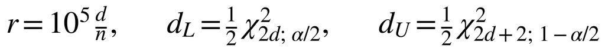

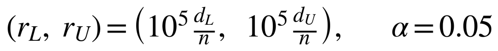

Eq. 1

Age- and sex-specific rates

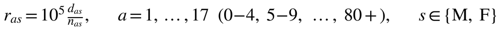

Eq. 2

Direct standardisation (WHO standard population)

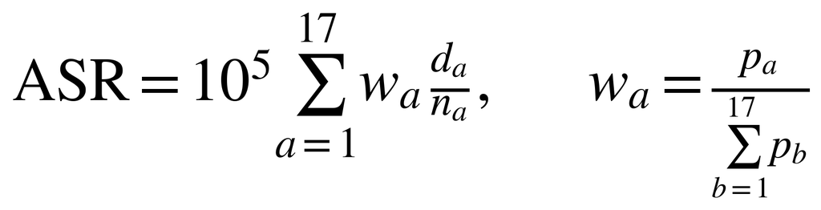

Eq. 3

Variance of the standardised rate and the w_M correction

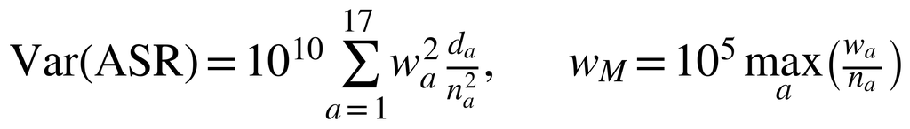

Eq. 4

Fay–Feuer gamma limits

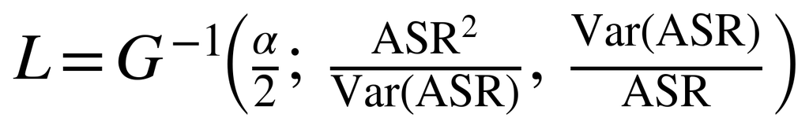

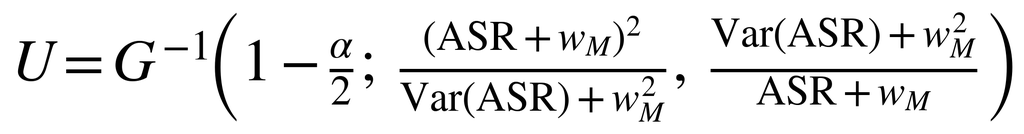

Eq. 5

Count ratio with exact binomial limits

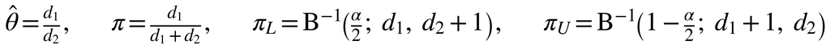

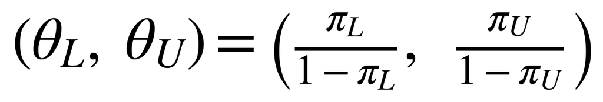

Eq. 6

Index numbers with a stated base year

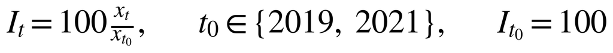

Eq. 7

### A7. Selected trend models and interpretation of sensitivity analyses

The retained trend models use a Poisson mean with log link and Pearson-scale dispersion estimation, conventionally described as quasi-Poisson log-linear models. The annual count is the outcome; time is years since the first year of the fitted window. The log denominator enters as a fixed-coefficient offset. National GRD models use matching episode counts as offsets, separate any-position and principal outcomes, and compare observed and stable panels and all activity with strict hospitalisation. Selected covariates are mean diagnostic depth among all episodes, centred within the model window, and an indicator for 2020–2021. These are descriptive adjustments and are not causal intervention terms.<sup>6</sup>

Hospital–year models include hospital indicator variables and a common time slope, with log hospital-year episodes as the offset. The selected robust specification clusters standard errors by hospital, allowing dependence within hospitals; it does not correct unknown cross-hospital dependence. Hospital-depth-adjusted specifications in the original analysis use model-based Pearson-scale standard errors and must not be described as hospital-clustered. National models likewise do not estimate a serial-correlation structure. Pearson dispersion and chronological deviance-residual Durbin–Watson summaries remain diagnostics, not evidence that the assumptions are satisfied.

Selected A05 models compare resident-population offsets, reporting-establishment offsets and stable-panel counts in 2021–2025; these estimate different quantities. P2 trend summaries are restricted to the comparable 2021–2025 age era, with count and establishment-offset specifications. Previously generated models spanning the 2021 P2 age expansion are not retained as estimates of a comparable full-period trend. Four to seven annual observations, and sometimes only two residual degrees of freedom after adjustment, make model-based intervals and p values fragile. The principal-diagnosis GRD model with depth and the 2020–2021 indicator is retained despite its uncertain annual percent change (APC) of −2·4% (95% interval −20·1 to 19·2). Stable-panel persistence or a positive adjusted coefficient does not identify how much of the observed increase each mechanism explains.

Selection is based on the question, validity and nonredundancy, not statistical significance; conflicting and null sensitivities are retained.

Y<sub>t</sub> is the recorded annual count, D<sub>t</sub> its specified denominator and Z<sub>t</sub> the selected covariate vector. With no offset, D<sub>t</sub>=1. Annual percent change (APC) intervals transform beta plus or minus 1·96 standard errors. They summarise a fitted log-linear trajectory, not an identified mechanism of change.

Quasi-Poisson log-linear model with offset and covariates

[figure not shown]

Eq. 8

Annual percent change, Wald interval and Pearson dispersion

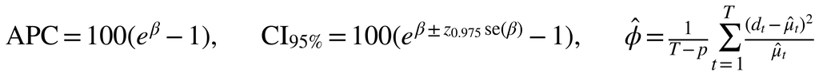

Eq. 9

Hospital fixed effects and cluster-robust variance

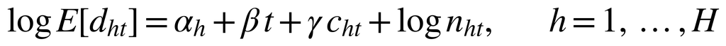

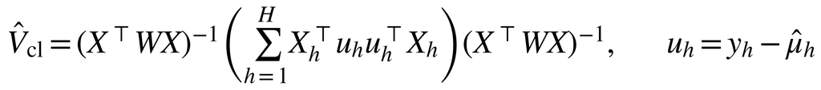

Eq. 10

Durbin–Watson on deviance residuals

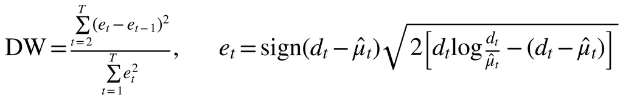

Eq. 11

### A8. Population surveys and design-based estimation

The population context comprises ENDIDE 2022 and ENCAVI 2023–24, analysed separately. ENDIDE targets people aged 2 years or older living in private dwellings, excluding hard-to-access areas outside its INE sampling frame. The selected-person file contains 35 536 respondents: 30 010 adults aged 18 years or older and 5 526 children aged 2–17 years. Adult autism reporting used c26_33 and child reporting used n29_19 (1=yes, 0=no); the latter was answered by the principal responsible adult. The adult module could be self-completed, assisted or answered through a third party. These labels identify a reported health condition and do not imply independent clinical assessment. No selected respondent lacked the autism item for their applicable module. Among children with autism reported, n29a_19 asks whether a doctor had said the child had autism; 1 denotes yes, 2 no and −99 nonresponse. The conditional primary denominator includes only valid yes/no answers. A separate estimate divides the number with both report and medical confirmation by the entire child domain, and a sensitivity analysis counts confirmation nonresponse as unconfirmed in the reporter domain.<sup>7–9</sup>

ENCAVI targets usual residents aged 15 years or older in occupied private dwellings in Chile’s 16 regions. The diagnosis item p4_6_1_h asks whether the respondent has been diagnosed with autism spectrum disorder; the questionnaire specifies a conventional medical diagnosis. The primary domain includes responses 1=yes or 2=no. Responses 8=do not know and 9=no response were excluded from that domain, while all sampling units were retained for variance estimation. A sensitivity analysis counts these responses as no reported diagnosis. Of 16 590 respondents, 16 484 provided a valid response, with 101 “do not know” and five nonresponses. The surveys differ in ages, questions, respondent type and year; estimates are not directly standardised to a common survey population and are not validation of GRD or REM.

Each survey proportion is the weighted ratio p̂<sub>D</sub> = Σ<sub>i</sub> w<sub>i</sub> D<sub>i</sub> y<sub>i</sub> / Σ<sub>i</sub> w<sub>i</sub> D<sub>i</sub>, where w<sub>i</sub> is the expansion weight, D<sub>i</sub> indicates membership in the analysis domain and y<sub>i</sub> is the binary response. ENDIDE uses fexp, estrato and cod_upm; ENCAVI uses w_personas_cal, varstrat and varunit. The variance uses Taylor linearisation with u<sub>i</sub> = w<sub>i</sub> D<sub>i</sub>(y<sub>i</sub>−p̂<sub>D</sub>)/Σ<sub>i</sub> w<sub>i</sub>D<sub>i</sub> and primary-sampling-unit totals within strata. Units outside a domain contribute zero rather than being deleted. A with-replacement first-stage variance is calculated as Σ<sub>h</sub> m<sub>h</sub>/(m<sub>h</sub>−1) Σ<sub>j</sub>(U<sub>hj</sub>−Ū<sub>h</sub>)², where m<sub>h</sub> is the number of primary sampling units (PSUs) in stratum h and U<sub>hj</sub>=Σ<sub>i</sub>∈hj u<sub>i</sub>. No finite-population correction is applied. Confidence limits use the logit transform and a t critical value with degrees of freedom equal to PSUs minus strata. The realised designs contain 8 477 PSUs in 32 strata for ENDIDE and 350 PSUs in 96 strata for ENCAVI; neither contains a singleton stratum. Weighted population totals are expansion-weight sums, and unweighted positive counts divided by domain sample size do not reproduce weighted percentages. Small subgroup cells (<30 positives) or relative standard error >30% were flagged as imprecise. The four national/domain estimates in figure 4c do not meet these flags.

We used the survey questions to define distinct reporting domains before examining age or sex. ENDIDE separates adults reporting autism, children with reported autism, and children whose report also includes physician confirmation. Confirmation is reported by the respondent and was not independently reassessed. Age and sex estimates were calculated within each domain using the complete survey design, retaining out-of-domain sampling units for variance estimation. The supplemental table reports weighted percentages alongside unweighted valid and positive counts, design-based confidence intervals and relative standard errors. Estimates with fewer than 30 positive responses or relative standard error above 30% remain visible but receive a precision warning. No regional or communal survey estimates were produced.

Survey ratio by Taylor linearisation

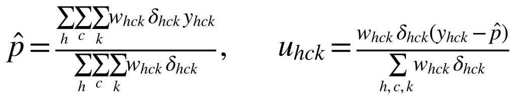

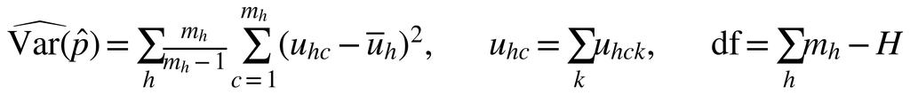

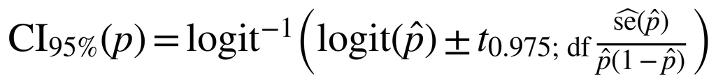

Eq. 12

Design effect, relative standard error and effective n

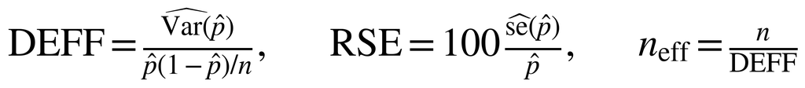

Eq. 13

#### Cross-system indices and sex composition

Trajectories were indexed descriptively as I<sub>st</sub> = 100 X<sub>st</sub>/X<sub>s,2021</sub> over the common 2021–24 window. X is the GRD rate per hospital activity, the strict A05 annual entry count, the P2 December children and adolescents with special health-care needs (NANEAS) stock for ages 0–19 years, or the harmonised PIE annual stock. P2’s age universe expands from 0–9 years in the 2019–20 dictionaries to 0–19 years from 2021; therefore the common 2021–24 index is calculated wholly within the expanded era. A stable establishment panel cannot correct this change in age eligibility. Thus an equal index measures equal relative change within each source, not an equal level or common population. No missing year was extrapolated. Male-to-female composition is the count ratio R<sub>t</sub>=M<sub>t</sub>/F<sub>t</sub> among records with those sex codes; it is not a ratio of sex-standardised population rates. Model-based 95% intervals transform exact Clopper–Pearson limits for p<sub>t</sub>=M<sub>t</sub>/(M<sub>t</sub>+F<sub>t</sub>) using p<sub>t</sub>/(1−p<sub>t</sub>), conditional on the sex-coded record total and an independent-binomial model. These intervals do not account for repeated contacts, hospital/facility clustering or coding error. GRD excludes records with unknown sex from this ratio; A05 uses the explicitly reported sex totals, which differ from some age-cell sums by one record in 2022, 2024 and 2025. In 2025 the reported male plus female total exceeds the both-sex A05 total by one. These source inconsistencies were preserved and the aggregate A05 flow uses its reported both-sex total.

### A9. Educational harmonisation

The PIE series follows the administrative programme rather than a fixed age-defined population. Apuntes 60 describes students in operating programme establishments across preschool, primary and secondary education, including youth and adult education; the selected autism tables do not provide an age-specific denominator. For 2019–2023, we added its historical autism and autism spectrum disorder (ASD)–Asperger categories and divided by all PIE students in the same table when describing programme composition. The report from the National Higher Education Quality Assurance System (SINACES) supplied subsequent autism totals and a distinct series for autism special schools. Its programme-applicant counts were kept separate from enrolment denominators. We retained the source transition and the five-student 2022 discrepancy explicitly, allowing readers to distinguish changes in recorded categories from harmonisation choices.<sup>10,11</sup>

The National Board of School Assistance and Scholarships (JUNAEB) school survey was examined but is not used for any estimate in this article. Its expansion weights do not supply the school-cluster and stratum information required for design-based inference; the 2023–24 autism variables contain positive selections and blanks rather than explicit negative responses, whereas 2025 adds explicit 0/1 values conditional on a medical-diagnosis filter, so a valid yes/no filter is not necessarily a complete autism outcome; and the 2024 grade-9 autism item is entirely empty and is therefore not estimable rather than zero. No JUNAEB figure, weighted interval or numerical claim appears in this article.

### A10. Screening and assisted referral by era

Screening and assisted referral were retained as supplementary context because their discontinuities show why a single continuous screening series would be misleading. In 2019–22, A03 (REM assessment-scale module) records Modified Checklist for Autism in Toddlers (M-CHAT) tests performed or altered among children already identified with language or social-area alteration. The 2023–24 Modified Checklist for Autism in Toddlers, Revised with Follow-Up (M-CHAT-R/F) categories are displayed separately, with first-part risk classifications and a second-part referral item. The additional 2024 indicators address ages 31–59 months. The 2025 redesign identifies M-CHAT-R/F results in ages 16–30 months and suspected autism at 30–59 months, retaining the published age boundary rather than harmonising it to the previous era. A27 (REM health-education module) assisted referrals are a separate annual count. Counts sum observed monthly values and report the number of establishments with a source record during that year; this is not evidence of complete reporting in every month at each establishment. All selected national series have records from 12 distinct months, including 2025, but network completeness is unknown. Missing items are not interpreted as zero. Repeated exact records have a small effect in selected A03 2024 counts (one low-risk record and four evaluations aged 31–59 months); the primary file totals and the deduplication sensitivity are retained. Independently aggregated items are not assumed to be nested person-level stages, and no conversion or referral-completion probability is calculated.<sup>2</sup>

### A11. Territorial methods and ecological comparisons

Territorial analyses used a fixed 346-commune Unique Territorial Code (CUT) crosswalk and INE resident population projections with a 2017 census base. GRD numerators locate episodes by reported residence; REM numerators locate activity at the reporting establishment. Therefore, REM divided by commune residents describes the spatial distribution of reported services relative to population and is not a risk estimate for those residents. The existing crosswalk harmonised commune codes and name aliases; all selected REM rows linked to it. Boundaries were kept fixed across years, with Ñuble represented consistently as region 16. No new boundary reconstruction was undertaken. Two GRD episodes with unknown residence were excluded from territorial numerators. A missing GRD residence–year row denotes no recorded eligible episode in the observed network, not complete ascertainment of autism among residents.

GRD spatial maps retained the 2019–2024 window. For commune c, E<sub>c</sub>=Σ<sub>tas</sub> N<sub>ctas</sub> r<sub>tas</sub>, where N is the resident population and r the national GRD episode rate for year t, age group a and sex s. Expected counts were multiplied by a common factor so that their total equalled the geocoded observed total; SIR<sub>c</sub>=O<sub>c</sub>/E<sub>c</sub>. Unknown-age/sex episodes remain in the observed numerator, so this calibration does not restore their missing covariates. Marshall empirical-Bayes smoothing shrank SIR<sub>c</sub> towards the overall ratio μ with weight w<sub>c</sub>=E<sub>c</sub>/(E<sub>c</sub>+μ/τ²), using the non-negative method-of-moments between-commune variance τ². Smoothed ratios are (w<sub>c</sub> SIR<sub>c</sub>)+(1−w<sub>c</sub>)μ; when τ²=0, all valid ratios shrink to μ. Crude commune ratios and alternative neighbourhood weights were retained as sensitivity analyses. Regional endpoint comparisons in Figure S6c are crude recorded episodes per 100 000 residents, with exact Poisson intervals; they are not age-standardised or estimates of uncertainty in network ascertainment.<sup>12</sup> Here, SIR denotes the indirectly standardised recorded-episode ratio, observed divided by expected episodes.

The spatial graph comprised 342 communes, preserving the existing continental restriction that excluded Juan Fernández (05104), Isla de Pascua (05201), Cabo de Hornos (12201) and Antártica (12202); only Cabo de Hornos retained geometry inside the displayed map extent. Polygon topology was retained when constructing queen contiguity; weights were standardised by row. Four islands in this graph (CUT 01404, 10206, 11203 and 12303) were attached to their nearest neighbour. Alternatives used four and eight nearest neighbours or inverse centroid distance, with a 142·31-km threshold ensuring at least one neighbour. Distances and map areas used a Chile-centred Albers equal-area projection. Global Moran I and local Moran statistics used the existing 999 permutations and seed 20260905; the local pseudo-p values were checked against the Benjamini–Hochberg threshold q=0·05 across 342 communes. A non-rejection is not evidence of spatial homogeneity. Maps preserve the original three geographic bands at the same metric scale; these layout bands do not define analytical macrozones.<sup>13–15</sup>

The Gini coefficient orders communes by their recorded-episode-to-resident ratio. Let X<sub>j</sub> and Y<sub>j</sub> be cumulative shares of resident population and recorded episodes after this ordering. G=1−Σ<sub>j</sub>(X<sub>j</sub>−X<sub>j−1</sub>)(Y<sub>j</sub>+Y<sub>j−1</sub>). Thus population weights, rather than equal commune weights, determine the Lorenz curve. All 346 communes, including true zero recorded counts, contribute. The same Gini calculation was repeated using the fixed 65-hospital GRD panel as a coverage sensitivity. Annual coverage is separately defined as the number with at least one recorded episode. Neither a smaller Gini nor a larger count of positive communes establishes equity or complete coverage.

The corrected cross-source analysis used 2021–2024 for all three indicators. A05 included only strict-autism entry code 05990022; P2 included P2500500 in December, covering ages 0–19 throughout this common window; the 2019–2020 age 0–9 era was not mixed into these correlations. Valid numeric rows, including zero, contributed; empty cells and absent rows did not become zero. A commune entered a pairwise analysis only if the relevant REM indicator had at least one valid establishment value in each of the four years. This rule establishes annual value presence, not monthly completeness or reporting by every establishment. One A05 row in 2024 had an empty total and was excluded; there were four reported-zero A05 rows across the window. Selected P2 December rows contained no reported zeros or empty totals. No selected exact duplicate or conflicting key was found. The stable-establishment sensitivity required a valid value from the same establishment in every common-window year; it likewise does not establish monthly completeness.

For flows, the window indicator was 100 000×Σ<sub>t</sub> O<sub>ct</sub>/Σ<sub>t</sub> N<sub>ct</sub>. P2 was explicitly the mean of the four December stocks for ages 0–19 divided by the mean of the four all-age resident populations, multiplied by 100 000. Algebraically this equals the ratio of sums, but the stock numerator is not interpreted as cumulative unique people. Spearman coefficients used unweighted territorial ranks with tied values averaged. Pair-specific complete commune sets were aggregated before computing regional coefficients, preserving a like-for-like geographical subset at the two scales. All three source pairs were retained. Limited sensitivities used a common three-source set, stable establishments, exclusion of positive counts of 1–4, exclusion of Metropolitana, raw standardised ratios, empirical Bayes (EB) ratios, counts without denominators and population-rank adjustment. A05 standardisation used the strict-autism national age–sex schedule; P2 had population-size standardisation only. Population-rank adjustment correlated residuals from separate regressions of each indicator rank on an intercept and the rank of mean population; it remained descriptive.

Ordinary Spearman p-values and Fisher-z intervals assume dependence structures not justified here. Independent resampling of communes would not resolve spatial dependence. A spatial block or spatial-surrogate analysis would require a justified block scale or null spatial model and sufficient independent units; these were not established in this bounded correction. Coefficients are therefore presented descriptively, without confidence intervals or significance stars. Bivariate Moran addresses association with neighbours and does not replace uncertainty for a same-commune Spearman coefficient; it was not used to infer referral or individual concordance. No externally justified pre-existing macrozone classification was identified, so a fourth within-macrozone correlation panel was omitted. This decision preserved the three specified source pairs without constructing zones from their observed association.

The dated original plan specified spatial false-discovery control if territorial analyses were included, but did not contain the detailed spatial specifications later stated in the implementation header. Existing GRD spatial analyses are retained as secondary exploratory analyses. Local cells with 1–4 positive episodes are hatched or omitted from scatter displays; their EB values and identifying labels are not displayed. True zero is shown separately. Correlation coefficients retain eligible low-count communes, with exclusion of such cells as a sensitivity.

Territorial displays suppress cells below five records; suppressed values and their ranks are not reported, and no display allows their reconstruction.

Indirect standardisation: expected counts and SIR

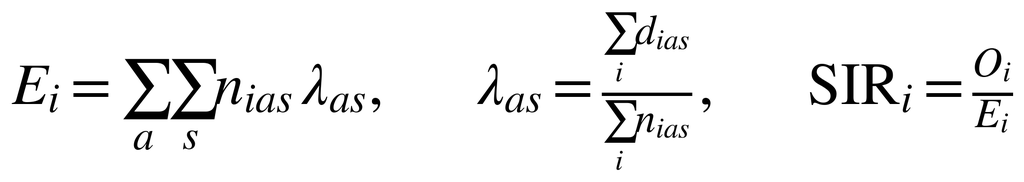

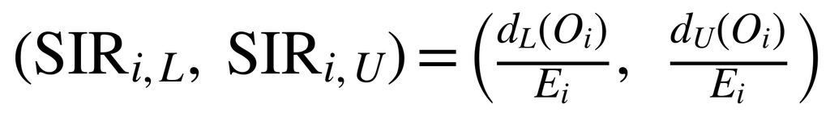

Eq. 14

Byar limits for the standardised ratio

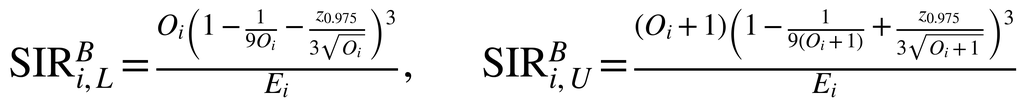

Eq. 15

Global empirical-Bayes shrinkage (Marshall)

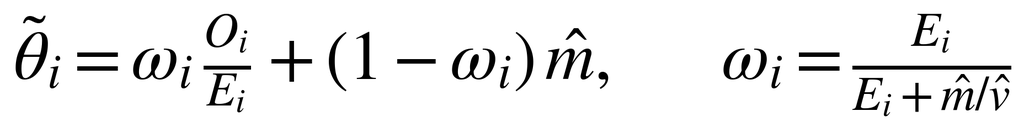

Eq. 16

Method-of-moments prior of the empirical-Bayes smoother

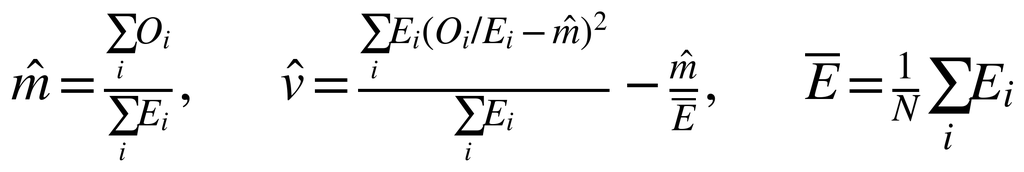

Eq. 17

Spearman's rho and the Fisher z interval

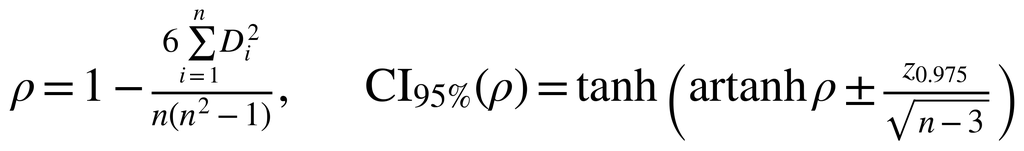

Eq. 18

Global Moran's I with queen contiguity and permutation p

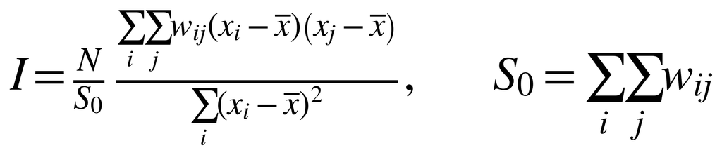

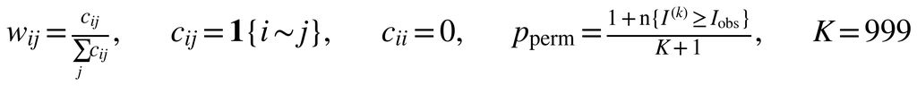

Eq. 19

Local indicators of spatial association (LISA)

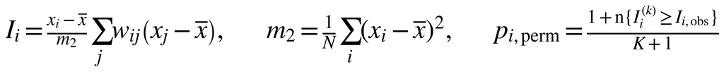

Eq. 20

Benjamini–Hochberg threshold

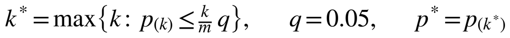

Eq. 21

Gini coefficient

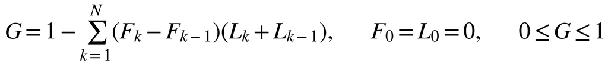

Eq. 22

Small-cell suppression rule

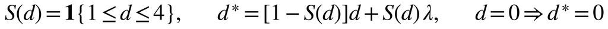

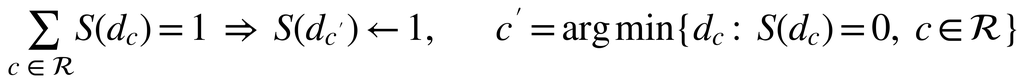

Eq. 23

## B. Complementary results

### B1. Age, sex, hospital robustness and complementary services

Figure S3 and table S7 retain age-specific and directly age-standardised public-network indicators by recorded sex. They use resident denominators without defining the population actually covered by the reporting network. Figure S2 collects the robustness analyses of the hospital indicator, figure S4 the stable reporting panels and the separate follow-up cuts of the REM series, and table S2 the selected definition and panel sensitivities.

GRD records showed both persistent childhood concentration and redistribution within younger ages. The known-age denominator was 2334 in 2019 and 8728 in 2024. The share aged 0–9 years fell from 55·7% to 47·7%, while ages 10–19 years increased from 33·2% to 40·8%; the adult share was 11·1% and 11·5%, respectively. In 2024 the highest male age-specific indicator occurred at 5–9 years: 2163 episodes among 622 349 residents, or 347·6 per 100 000 (95% confidence interval [CI] 333·1–362·5). For females, the peak was at 10–14 years: 893 episodes among 634 559 residents, or 140·7 (131·6–150·3). Both-sex age-standardised indicators increased from 15·8 (15·2–16·5) to 59·3 (58·1–60·6) per 100 000 residents. The female and male standardised indicators increased approximately 5·13-fold and 3·32-fold, respectively; these descriptive changes are not a formal test of differences between sex-specific trends. Four episodes with known age but unknown sex explain the difference between the 2024 known-age denominator of 8728 and the 8724 records used in age standardisation.

A05 age-cell distributions showed a larger relative increase among adolescents and adults than among younger children, although children still contributed the largest count in 2025. Ages 0–9, 10–19 and 20 years or older accounted for 6143 (46·7%), 5808 (44·1%) and 1205 (9·2%) of 13 156 age-cell entries. Male and female indicators peaked at 5–9 years: 3538 entries among 610 433 male residents, or 579·6 per 100 000 (95% CI 560·6–599·0), and 1298 among 587 777 female residents, or 220·8 (209·0–233·2). The combined standardised indicator increased from 14·3 (13·7–14·9) in 2021 to 90·2 (88·7–91·8) in 2025. The standardisation series uses 4641 age-cell entries in 2022 and 11 843 in 2024, each one above the corresponding overall total. Together with the one-entry discrepancy in 2025, these differences are preserved as source inconsistencies rather than corrected by deleting an arbitrary cell.

The overall mean number of coded diagnoses increased from 4·39 to 5·78 per episode, compared with 4·97 to 6·00 among eligible episodes. Within the three-diagnosis stratum, eligible coding increased from 491 of 166 601 episodes to 1378 of 129 028; the corresponding indicators were 294·7 (95% CI 269·2–322·0) and 1068·0 (1012·3–1125·9) per 100 000. By contrast, the one-diagnosis stratum remained uncommon and imprecise: 26 of 200 436 episodes in 2019 and 22 of 133 658 in 2024, or 13·0 (8·5–19·0) and 16·5 (10·3–24·9) per 100 000. This low-depth stratum is retained despite its weaker change. Hospital-specific indicators in 2024 had an unweighted median of 638·0, interquartile range 393·3–976·1 and maximum 5210·7. One hospital with fewer than five eligible episodes is suppressed in figure S2ca. These differences can reflect service mix, referral patterns and recording practices; they should not be ranked as differences in population risk or quality of care.

The national Department of Health Statistics and Information (DEIS) discharge series provides a principal-diagnosis comparison with a broader establishment universe. Eligible principal diagnoses increased from 304 among 1 667 180 discharges in 2019 to 678 among 1 667 349 in 2024, corresponding to 18·2 (95% CI 16·2–20·4) and 40·7 (37·7–43·8) per 100 000 discharges. In 2024, 581 of 678 eligible DEIS discharges (85·7%) were classified as National Health Services System (SNSS) discharges. The comparison supports a rise in administrative principal-diagnosis recording across both sources, but differing establishment coverage and episode definitions prevent interpretation as capture probabilities or linked validation. DEIS does not provide a secondary-diagnosis series equivalent to the GRD any-position numerator. In GRD, the principal trend adjusted simultaneously for mean coding depth and the 2020–2021 indicator was −2·4% annually (95% CI −20·1 to 19·2), based on six observations and two residual degrees of freedom. This unfavourable and imprecise sensitivity is retained alongside the more stable descriptive endpoints.

P2 robustness was assessed within the comparable 2021–2025 age universe as well as using a restricted known-age numerator. December totals increased from 3853 to 29 974, compared with 1748 to 9128 in the 193-establishment panel present across all seven years. Restricting stable membership to the current age era retained 433 establishments and stocks of 3105 in 2021 and 17 509 in 2025. Summing the same under-10 age cells across years yielded 3518 in 2021 and 25 162 in 2025; within the 193-establishment panel these sums were 1655 and 7632. These are known-age sums: all under-10 age cells were blank in 12 December rows in 2021 and 18 in 2025. Consistent age restriction therefore supports increased recorded follow-up while leaving some numerator incompleteness unresolved. Neither stable membership nor a reporting-establishment offset repairs the expansion from ages <10 to <20 years in 2021, and no continuous 2019–2025 P2 trend is interpreted.

Within the strict-autism era, P6 primary-care December stocks were 2257, 5042, 9717, 15 934 and 21 843 from 2021 through 2025; the corresponding numbers of reporting establishments were 482, 704, 956, 1160 and 1274. Specialty stocks were 3562, 4684, 7982, 8835 and 12 645, reported by 95, 113, 129, 144 and 153 establishments. The earlier broad pervasive developmental disorders (PDD) categories in 2019–2020 remain separate. A28 primary-care rehabilitation entries rose from 3962 to 7033 to 15 859 in 2023–2025, with 264, 313 and 359 establishments; hospital rehabilitation entries were 731, 1045 and 1740, with 39, 50 and 43 establishments. Thus hospital rehabilitation entries increased in 2025 despite a lower number of establishments with rows. None of these aggregates identifies which individuals entered, remained in, or completed another service stage.

### B2. Educational, survey and screening context

The harmonised PIE count increased from 21 012 in 2019 to 106 786 in 2025, a 5·08-fold increase across the labelled source transition. The 2019–23 increase was present in both historical categories: 11 877 to 47 551 in the ASD category and 9 135 to 16 091 in ASD–Asperger. In the common 2021–24 window, all four indexed administrative indicators increased; these trajectories describe relative recorded growth rather than comparable levels.

The harmonised autism share of PIE increased even as overall programme enrolment expanded. The autism component increased approximately fourfold between 2019 and 2023, whereas ASD–Asperger increased less than twofold. This different composition is informative alongside the combined trajectory, but cannot determine whether diagnostic substitution occurred within individuals. The distinct autism-special-school series increased from 2074 in 2022 to 2298 in 2023, 2505 in 2024 and 2626 in 2025. The corresponding SINACES combined totals for PIE and autism special schools were 45 014, 65 940, 88 980 and 109 412. These totals omit autistic pupils in other special-school categories and in regular establishments outside PIE, as the source report specifies.

ENDIDE estimated reported autism in 0·29% (95% CI 0·22–0·38) of adults aged 18 years or older and 2·87% (2·37–3·47) of children aged 2–17 years. Reported autism with medical confirmation represented 2·39% (1·94–2·95) of all children; among children with reported autism and valid confirmation responses, 90·00% (82·30–94·57) reported confirmation. Counting the 10 confirmation nonresponses as unconfirmed reduced that conditional estimate to 83·46% (74·92–89·50). ENCAVI estimated reported medical diagnosis in 0·71% (0·50–1·01) of valid respondents aged 15 years or older. Counting its 106 missing/unknown responses as no diagnosis produced 0·707%, compared with 0·713% in the valid-response analysis.

In ENDIDE adults, reported autism was 0·44% (95% CI 0·32–0·61) in males and 0·15% (0·09–0·24) in females; the female estimate rested on 24 positive responses. The estimate was 0·62% (0·42–0·91) at ages 18–29, compared with 0·33%, 0·15% and 0·06% in successively older groups, each of which contained fewer than 30 positives. These are cross-sectional age contrasts. Requiring physician confirmation in children yielded 3·79% (3·01–4·77) in boys and 0·95% (0·62–1·45) in girls, with 28 confirmed-positive girls. All ENCAVI age-specific domains triggered a precision warning, including ages 30–49, with 30 positives but a relative standard error of 30·8%. Their uncertainty does not support a finely resolved age gradient or geographical extrapolation.

The male-to-female record ratio declined from 3·27 to 2·03 in GRD during 2019–24 and from 3·52 to 2·07 in A05 during 2021–25. These descriptive changes concern the composition of recorded episodes and entries. They do not estimate a change in the underlying sex-specific risk of autism.

Legacy A03 screening counts were 2613 in 2019, 816 in 2020, 1833 in 2021 and 3455 in 2022. The 2019 series includes an unusually concentrated February entry, retained with its documented sensitivity rather than converted into a screening-positivity estimate. Within the redesigned 2023–2024 era, low-risk records increased from 14 083 to 18 142 and high-risk records from 1907 to 2234; high-risk reporting establishments increased from 478 to 552. The additional 31–59-month group in 2024 recorded 39 466 evaluations at integral health checks in 694 establishments; removing four exact duplicate records gave 39 462. The 2025 redesign distinguished screening motives and referral requirements and used 30–59 months for its older group. Consequently, 2025 categories are displayed separately from the preceding eras, even when labels resemble earlier categories.

February 2019 contributed 1 051 performed and 1 028 altered records, a previously identified file anomaly retained in the descriptive totals; omitting that month leaves 1 562 performed and 612 altered records. No screening positivity estimate is advanced from these counts.

The complementary A27 trajectory was not uniformly increasing. Assisted referrals in the screening context rose from 672 records in 98 establishments in 2023 to 1068 in 118 establishments in 2024, then declined to 878 in 114 establishments in 2025. Counselling records in the same context followed a similar sequence: 2380, 3874 and 3026, respectively, with 150, 180 and 169 reporting establishments. These contrasting trajectories are retained because they describe a relevant service activity even though the main programme indicators increased. The aggregate data cannot determine whether the 2025 decline reflects fewer referrals, changes in how contacts were recorded, or differences in reporting coverage; nor can A27 be linked to individual A03 evaluations.

Figures 3a and S4c keep the screening and referral eras separate; table S3B reports the full selected survey domains and precision flags, and table S5 records educational category and denominator harmonisation. Figure 4c reports the population-survey benchmarks, figure 1e the male-to-female record ratio, and figure S5 the JUNAEB caregiver reports, crude records per resident across systems and the composition of the School Integration Programme.

### B3. Territorial distribution and ecological associations

The crude GRD episode indicator increased in every region between 2019 and 2024, although levels and relative changes remained heterogeneous. In 2019, rates ranged from 7·86 per 100 000 residents in Maule (95% CI 6·31–9·69) to 35·23 in Magallanes (27·01–45·16). In 2024, the range was 27·37 in Los Ríos (22·56–32·91) to 71·88 in Ñuble (64·79–79·54). Metropolitana contributed 697 eligible episodes in 2019 and 2 754 in 2024, against resident denominators of 7 915 199 and 8 420 729. The regional table includes all 16 regions; two episodes with unknown residence in 2019 are excluded from regional numerators. These are episode indicators divided by residents, with exact Poisson intervals conditional on the recorded counts and denominators.

Of 25 323 eligible GRD episodes in 2019–2024, 25 321 were assigned to a commune of residence; two episodes in 2019 had unknown residence. The full-window empirical-Bayes GRD ratio showed spatial clustering (Moran I=0·340 with queen contiguity; 999-permutation pseudo-p=0·001). The Gini decline persisted in the fixed panel of 65 hospitals (0·373 in 2019 to 0·293 in 2024; 242 to 302 communes with records). Moran I was 0·266 for the unsmoothed indirectly standardised ratio and 0·239 for the crude resident-denominator indicator. The EB coefficient ranged from 0·230 with inverse-distance weights to 0·354 with four nearest neighbours. Local analysis identified 12 high–high, six low–low and one low–high commune after Benjamini–Hochberg correction; 323 communes did not pass the threshold. None of the 19 flagged communes had fewer than five episodes.

Common-window correlations used 157 communes for GRD–A05, 236 for GRD–P2 and 133 for A05–P2. The respective descriptive coefficients were 0·341, 0·109 and 0·321. Aggregating the same pair-specific commune sets to regions yielded 0·224 (16 regions), 0·591 (16 regions) and 0·225 (15 regions); Magallanes had no commune meeting the combined A05–P2 reporting rule. These regional indicators describe the included commune subsets, rather than complete regional totals. The weak GRD–P2 commune association contrasted with the stronger regional coefficient, illustrating sensitivity to geographical aggregation.

Restricting REM to establishments with a valid value in every year of the common window yielded coefficients of 0·296, 0·126 and 0·313 for the same three pairs, with 144, 212 and 111 communes, respectively. Excluding Metropolitana attenuated them to 0·239, 0·023 and 0·095. Using the common set of 133 communes with all three indicators gave 0·314, 0·174 and 0·321. Empirical-Bayes smoothing gave 0·355, 0·176 and 0·319. Counts without a resident denominator were much more strongly associated (0·798, 0·818 and 0·678), consistent with shared territorial scale influencing count comparisons; this does not identify a causal denominator effect. The population-rank residual sensitivity gave 0·419, 0·277 and 0·269. Using an age-compatible P2 denominator restricted to residents aged 0–19 gave 0·080 for GRD–P2 (236 communes) and 0·310 for A05–P2 (133 communes), retaining the weak GRD–P2 association (Table S6). No confidence intervals or significance claims were attached to these ecological correlations.

Figures S6 and S7 and tables S6 and S8 separate full-window spatial distribution from common-window ecological comparisons; figure 4d shows the commune-level comparison between hospital episodes and programme entries.

### B4. Hospital clinical context

The hospital signal spanned several clinical contexts. Among the 8341 episodes with an eligible code only in a secondary position in 2024, the four most frequent principal three-character categories were depressive episode (380, 4·6%), redundant prepuce, phimosis or paraphimosis (373, 4·5%), epilepsy (358, 4·3%), and acute appendicitis (324, 3·9%). No individual principal category accounted for 5% of these episodes. The selected principal categories and accompanying diagnostic chapters are reported in supplementary table S9.

In 2024, non-F84 mental and behavioural codes accompanied 3549 of 8731 eligible episodes (40·6%), respiratory codes 3021 (34·6%), and endocrine, nutritional or metabolic codes 2453 (28·1%). Nervous-system codes appeared in 1566 episodes (17·9%). Factors influencing health status and contact with health services were recorded in 4436 episodes (50·8%). These chapter percentages overlap. The variety of principal categories among secondary-only episodes, including psychiatric, neurological, surgical and respiratory contacts, further shows why the main hospital indicator is broader than admission primarily for autism (table S9).

Table S1. Sources, selected definitions and structural breaks

| Source / years | Selected code or definition | Unit / key limitation |
| --- | --- | --- |
| GRD 2019–2024 | F84, F84.0, .1, .3, .4, .5, .8, .9 | Episode; any/principal/secondary-only positions; hospital activity denominator |
| A05 2019–2020 | 06902600 (entries); 05225000 (discharges) | Broad PDD flow; cannot separate Rett or later strict autism |
| A05 2021–2025 | 05990022 strict entries; family 05990022/23/25/26 | Annual flow; Rett family category 05990024 excluded |
| P2 2019–2020 | P2500500; under-10 age-by-sex columns | June/December stocks, ages <10 years |
| P2 2021–2025 | P2500500; adds age columns for ages 10–19 | June/December stocks, ages <20 years; break at 2021 |
| P6 2019–2020 | P6223000 primary; P6223380 specialty | Broad PDD stock; no connection to strict era |
| P6 2021–2025 | P6241010 primary; P6241060 specialty | Strict-autism stocks; December main, June separate |
| A28 2023–2025 | 29101629 primary; 29101651 hospital | Annual rehabilitation-entry flows |
| A03 2019–2022 / 2023–2024 / 2025 | 03500406/07; 09600212–19; 03710013–21 | Screening eras separated; additional 31–59-month group in 2024 (03700104–09) |
| A27 2023–2025 | 29101574 assisted referral | Annual activities; no linked screening-to-referral conversion |

F84.2 does not confer GRD eligibility; an episode with another eligible code remains included when Rett coexists. Broad REM families are separate from strict autism. P2’s 2021 age expansion was identified during the revision by inspecting complete age headers, not only unchanged code labels. Source-specific survey and education details follow in their methods and tables. Abbreviations: GRD=diagnosis-related groups; REM=Monthly Statistical Summaries; A05=REM mental-health entry module; P2=REM child/adolescent special-health-needs follow-up module; P6=REM mental-health follow-up module; A28=REM rehabilitation module; A03=REM assessment-scale module; A27=REM health-education module; PDD=pervasive developmental disorders.

Table S2A. Hospital definition and panel sensitivities at the period endpoints

| Definition / panel | 2019 episodes | 2019 rate (95% CI) | 2024 episodes | 2024 rate (95% CI) |
| --- | --- | --- | --- | --- |
| Selected definition; observed | 2 334 | 202·7 (194·6–211·1) | 8 731 | 804·1 (787·3–821·1) |
| Selected definition; stable65 | 2 334 | 202·7 (194·6–211·1) | 8 480 | 808·6 (791·5–826·0) |
| Full F84 incl. Rett; observed | 2 385 | 207·1 (198·9–215·6) | 8 818 | 812·1 (795·2–829·2) |
| F84.0 only; observed | 1 400 | 121·6 (115·3–128·1) | 7 230 | 665·9 (650·6–681·4) |

All GRD activity; any eligible diagnostic position. Same-panel yearly episode denominators. Coexisting Rett + another eligible code is retained: 4 episodes in 2019 and 7 in 2024. Removing Rett as an eligible code excludes 51 and 87 episodes respectively. Abbreviations: GRD=diagnosis-related groups; CI=confidence interval.

Table S2B. P2 common-age and comparable-era panel sensitivities

| Year | Known <10 age-cell sum | Known <10 sum: stable193 | Rows with empty <10 age cells | Reported total: stable433 |
| --- | --- | --- | --- | --- |
| 2019 | 1 854 | 1 040 | 0 | — |
| 2020 | 1 919 | 1 154 | 0 | — |
| 2021 | 3 518 | 1 655 | 12 | 3 105 |
| 2022 | 7 478 | 2 841 | 6 | 5 422 |
| 2023 | 12 051 | 4 328 | 15 | 8 725 |
| 2024 | 19 226 | 6 123 | 14 | 12 595 |
| 2025 | 25 162 | 7 632 | 18 | 17 509 |

The <10 indicator sums the known age-by-sex cell values. Entirely empty age rows remain missing; this is a known-cell sum, not a complete age-specific count. In 2019–2020 the published universe was <10, explaining equality with the reported total. The 433-panel requires a December row in every year 2021–2025 and is shown only within that comparable era; it is a revision-stage sensitivity. Abbreviations: REM=Monthly Statistical Summaries; P2=REM child/adolescent special-health-needs follow-up module.

Table S2C. Selected trend specifications, denominators and uncertainty metadata

| Specification / years | Unit, offset, covariates and SE | APC, % (95% CI) | n / residual df | Pearson dispersion |
| --- | --- | --- | --- | --- |
| GRD any position, observed 2019-2024 | Annual national totals; log(all episodes); linear year Pearson-scaled model SE | 35·9 (30·0–42·1) | 6 / 4 | 33·19 |
| GRD any position, fixed 65 2019-2024 | Annual fixed-panel totals; log(panel episodes); linear year Pearson-scaled model SE | 36·1 (30·1–42·5) | 6 / 4 | 34·13 |
| GRD any position + coding depth 2019-2024 | Annual national totals; log(all episodes); year + centred mean diagnoses Pearson-scaled model SE | 46·9 (40·8–53·3) | 6 / 3 | 6·55 |
| GRD any position + 2020–2021 indicator 2019-2024 | Annual national totals; log(all episodes); year + 2020–2021 indicator Pearson-scaled model SE | 32·9 (28·4–37·6) | 6 / 3 | 15·06 |
| GRD principal diagnosis 2019-2024 | Annual national totals; log(all episodes); linear year Pearson-scaled model SE | 14·6 (10·2–19·3) | 6 / 4 | 1·97 |
| GRD principal + depth + 2020–2021 2019-2024 | Annual national totals; log(all episodes); year + depth + indicator Pearson-scaled model SE | -2·4 (-20·1–19·2) | 6 / 2 | 0·76 |
| GRD hospital fixed effects; clustered SE 2019-2024 | Hospital–year; log(hospital episodes); hospital fixed effects + year Hospital-clustered robust SE | 35·9 (32·0–40·0) | 400 / 327 | 3·83 |
| GRD hospital fixed effects + depth 2019-2024 | Hospital–year; log(hospital episodes); hospital fixed effects + year + depth Pearson-scaled model SE | 34·2 (31·6–36·8) | 400 / 326 | 3·78 |
| A05 strict entries / residents 2021-2025 | Annual national totals; log(INE residents); linear year Pearson-scaled model SE | 47·2 (27·4–70·0) | 5 / 3 | 355·73 |
| A05 strict entries / reporting establishments 2021-2025 | Annual national totals; log(annual establishments); linear year Pearson-scaled model SE | 27·9 (23·7–32·2) | 5 / 3 | 16·54 |
| A05 stable 258 / residents 2021-2025 | Annual stable-panel totals; log(INE residents); linear year Pearson-scaled model SE | 38·5 (26·8–51·2) | 5 / 3 | 73·86 |
| P2 December stock, comparable age era 2021-2025 | Annual national December stocks; no offset; linear year Pearson-scaled model SE | 60·1 (48·3–72·8) | 5 / 3 | 178·79 |
| P2 December stock / reporting establishments 2021-2025 | Annual national December stocks; log(December establishments); linear year Pearson-scaled model SE | 37·1 (31·6–42·8) | 5 / 3 | 48·84 |

All displayed fits are log-link Poisson GLMs with quasi-Poisson (Pearson) scale; annual percentage change (APC)=100[exp(year coefficient)−1], with normal-Wald 95% intervals. Annual national models contain only five or six time points; their observations and residual degrees of freedom are shown. Hospital fixed effects use 400 hospital–year observations from 72 hospitals observed at least once, with a common annual slope. Only the explicitly labelled clustered fit uses robust standard errors grouped by hospital; the coding-depth fixed-effects fit uses model-based, Pearson-scaled standard errors. None of the national models adjusts for serial correlation. The 2020–2021 indicator and coding-depth covariate are descriptive sensitivities, not estimates of mechanisms or policy effects. The principal diagnosis model with both covariates is imprecise and compatible with no increase; it has only two residual degrees of freedom. P2 2019–2025 models are omitted because they cross the 2021 age-universe expansion; only existing models confined to 2021–2025 are retained. Reporting-establishment offsets change the estimand to stock or entries per establishment; they do not measure population coverage. Model selection reflects denominator, panel and definition questions and retains the adverse sensitivity, not a statistical-significance threshold. df=residual degrees of freedom. Abbreviations: REM=Monthly Statistical Summaries; GRD=diagnosis-related groups; A05=REM mental-health entry module; P2=REM child/adolescent special-health-needs follow-up module; INE=National Statistics Institute; CI=confidence interval; SE=standard error; GLM=generalised linear model.

Table S2D. Principal-diagnosis comparison across nonlinked discharge sources

| Source / year | Principal eligible records | Own activity denominator | Rate /100 000 (95% CI) |
| --- | --- | --- | --- |
| DEIS 2019 | 304 | 1 667 180 | 18·2 (16·2–20·4) |
| GRD 2019 | 228 | 1 151 475 | 19·8 (17·3–22·5) |
| DEIS 2024 | 678 | 1 667 349 | 40·7 (37·7–43·8) |
| GRD 2024 | 390 | 1 085 813 | 35·9 (32·4–39·7) |

DEIS covers all published hospital discharges; GRD covers participating public hospitals. The diagnostic position is aligned (principal) but coverage and episode definitions remain different, so the table is contextual and does not estimate capture, sensitivity or linkage concordance. DEIS cannot reproduce GRD secondary-diagnosis ascertainment. Published DEIS establishment masking further limits site matching. Abbreviations: GRD=diagnosis-related groups; DEIS=Department of Health Statistics and Information; CI=confidence interval.

Table S3A. Survey samples, weighted estimators and missing-response sensitivity

| Survey/domain | Eligible sample | Positive/analysis n (unweighted) | Weighted numerator/denominator | Weighted % (95% CI) | Missing item n |
| --- | --- | --- | --- | --- | --- |
| Adults ≥18: report | 30 010 | 72/30 010 | 44 594/15 355 960 | 0·29 (0·22–0·38) | 0 |
| Children 2–17: report | 5 526 | 163/5 526 | 114 497/3 992 965 | 2·87 (2·37–3·47) | 0 |
| Children 2–17: report + confirmation | 5 526 | 139/5 526 | 95 560/3 992 965 | 2·39 (1·94–2·95) | 10 |
| Confirmation among reporters, valid answers | 163 | 139/153 | 95 560/106 175 | 90·00 (82·30–94·57) | 10 |
| Confirmation, missing=unconfirmed | 163 | 139/163 | 95 560/114 497 | 83·46 (74·92–89·50) | 10 |
| ENCAVI ≥15: diagnosis, valid answers | 16 590 | 80/16 484 | 114 817/16 113 518 | 0·71 (0·50–1·01) | 106 |
| ENCAVI ≥15: diagnosis, missing=no | 16 590 | 80/16 590 | 114 817/16 238 022 | 0·71 (0·50–1·01) | 106 |

All ENDIDE rows refer to 2022; ENCAVI refers to 2023–24. Weighted totals are rounded for display; estimates use unrounded weights. A confirmation item is asked only if child autism is reported; the 10 confirmation nonresponses are retained as not confirmed in the whole-child composite and in the explicitly labelled sensitivity. Missing ENCAVI diagnosis comprises 101 do-not-know and five nonresponses. Primary proportions use domain-based Taylor variance, with full design retained: ENDIDE fexp/estrato/cod_upm, 8 477 PSUs/32 strata; ENCAVI w_personas_cal/varstrat/varunit, 350 PSUs/96 strata. Neither survey is a clinical validation study. Abbreviations: ENDIDE=National Disability and Dependency Survey; ENCAVI=National Quality of Life and Health Survey; CI=confidence interval; PSU=primary sampling unit.

Table S3B. Age and sex domains in the population surveys

| Domain | Valid n | Positive n | Weighted % (95% CI) | RSE, % | Precision |
| --- | --- | --- | --- | --- | --- |
| **ENDIDE 2022: reported autism, adults ≥18 years** |  |  |  |  |  |
| Male | 12696 | 48 | 0·44 (0·32–0·61) | 16·7 | Unflagged |
| Female | 17314 | 24 | 0·15 (0·09–0·24) | 23·8 | Limited |
| 18–29 years | 5953 | 36 | 0·62 (0·42–0·91) | 19·5 | Unflagged |
| 30–44 years | 6820 | 22 | 0·33 (0·20–0·54) | 24·9 | Limited |
| 45–59 years | 8066 | 9 | 0·15 (0·07–0·33) | 39·0 | Limited |
| 60+ years | 9171 | 5 | 0·06 (0·02–0·15) | 48·8 | Limited |
| **ENDIDE 2022: reported autism, children 2–17 years** |  |  |  |  |  |
| Male | 2880 | 129 | 4·57 (3·70–5·63) | 10·7 | Unflagged |
| Female | 2646 | 34 | 1·11 (0·75–1·63) | 19·8 | Unflagged |
| 2–5 years | 1053 | 45 | 3·45 (2·34–5·05) | 19·6 | Unflagged |
| 6–11 years | 2131 | 68 | 3·33 (2·50–4·41) | 14·5 | Unflagged |
| 12–17 years | 2342 | 50 | 2·17 (1·57–2·98) | 16·3 | Unflagged |
| **ENDIDE 2022: reported autism and reported physician confirmation, children 2–17 years** |  |  |  |  |  |
| Male | 2880 | 111 | 3·79 (3·01–4·77) | 11·8 | Unflagged |
| Female | 2646 | 28 | 0·95 (0·62–1·45) | 21·7 | Limited |
| 2–5 years | 1053 | 38 | 2·79 (1·81–4·29) | 22·0 | Unflagged |
| 6–11 years | 2131 | 61 | 2·95 (2·18–3·99) | 15·4 | Unflagged |
| 12–17 years | 2342 | 40 | 1·68 (1·18–2·39) | 18·0 | Unflagged |
| **ENCAVI 2023–2024: reported physician diagnosis, ages ≥15 years** |  |  |  |  |  |
| Male | 5225 | 35 | 0·97 (0·61–1·54) | 23·6 | Unflagged |
| Female | 11259 | 45 | 0·46 (0·30–0·73) | 22·7 | Unflagged |
| 15–19 years | 475 | 4 | 1·65 (0·54–4·93) | 56·5 | Limited |
| 20–29 years | 1743 | 28 | 1·60 (0·93–2·74) | 27·3 | Limited |
| 30–49 years | 4550 | 30 | 0·60 (0·32–1·09) | 30·8 | Limited |
| 50–64 years | 4727 | 12 | 0·28 (0·13–0·60) | 38·0 | Limited |
| 65+ years | 4989 | 6 | 0·14 (0·05–0·39) | 53·1 | Limited |

Percentages and confidence intervals retain the complete stratified clustered survey design. Displayed n values are unweighted. RSE=relative standard error. Limited precision denotes fewer than 30 positive responses or RSE>30%; estimates remain visible. Age and sex are separate overlapping partitions, not independent samples. Estimates do not measure temporal change or clinically reassessed prevalence. Abbreviations: ENDIDE=National Disability and Dependency Survey; ENCAVI=National Quality of Life and Health Survey; CI=confidence interval.

Table S4A. Complementary rehabilitation and follow-up

| Module / setting | Code | Year | Count | Reporters | Unit |
| --- | --- | --- | --- | --- | --- |
| P6 Primary care | P6241010 | 2021 | 2 257 | 482 | December stock |
| P6 Primary care | P6241010 | 2022 | 5 042 | 704 | December stock |
| P6 Primary care | P6241010 | 2023 | 9 717 | 956 | December stock |
| P6 Primary care | P6241010 | 2024 | 15 934 | 1160 | December stock |
| P6 Primary care | P6241010 | 2025 | 21 843 | 1274 | December stock |
| P6 Specialty care | P6241060 | 2021 | 3 562 | 95 | December stock |
| P6 Specialty care | P6241060 | 2022 | 4 684 | 113 | December stock |
| P6 Specialty care | P6241060 | 2023 | 7 982 | 129 | December stock |
| P6 Specialty care | P6241060 | 2024 | 8 835 | 144 | December stock |
| P6 Specialty care | P6241060 | 2025 | 12 645 | 153 | December stock |
| A28 Primary care | 29101629 | 2023 | 3 962 | 264 | Annual entries |
| A28 Primary care | 29101629 | 2024 | 7 033 | 313 | Annual entries |
| A28 Primary care | 29101629 | 2025 | 15 859 | 359 | Annual entries |
| A28 Hospital | 29101651 | 2023 | 731 | 39 | Annual entries |
| A28 Hospital | 29101651 | 2024 | 1 045 | 50 | Annual entries |
| A28 Hospital | 29101651 | 2025 | 1 740 | 43 | Annual entries |

P6 presents strict autism from 2021, separately from the broader 2019–2020 category shown in figure 3. P6 stocks from different cuts or settings are not added as unique people. Counts sum known source values; reporters indicate establishments with the selected code at that cut or during the year. Abbreviations: REM=Monthly Statistical Summaries; P6=REM mental-health follow-up module; A28=REM rehabilitation module.

Table S4B. Selected screening and referral records by definition era

| Code | Years | Item | Annual records, chronological | Annual reporting establishments |
| --- | --- | --- | --- | --- |
| 03500406 | 2019–22 | M-CHAT performed | 2 613; 816; 1 833; 3 455 | 263; 198; 273; 399 |
| 03500407 | 2019–22 | M-CHAT altered | 1 640; 288; 879; 1 535 | 188; 134; 230; 315 |
| 09600213 | 2023–24 | M-CHAT-R/F part 1, low risk | 14 083; 18 142 | 880; 1082 |
| 09600214 | 2023–24 | Part 1, medium risk | 3 642; 4 698 | 627; 734 |
| 09600215 | 2023–24 | Part 1, high risk | 1 907; 2 234 | 478; 552 |
| 09600219 | 2023–24 | Part 2, referral | 1 136; 2 283 | 346; 516 |
| 03700104 | 2024 | 31–59 months, evaluated | 39 466 | 694 |
| 03700106 | 2024 | 31–59 months, alert yes | 5 860 | 674 |
| 03700108 | 2024 | 31–59 months, referral yes | 4 866 | 629 |
| 03710016 | 2025 | 16–30 months, low risk | 12 971 | 818 |
| 03710017 | 2025 | 16–30 months, medium/no referral | 1 637 | 395 |
| 03710018 | 2025 | 16–30 months, medium/referral | 2 500 | 534 |
| 03710019 | 2025 | 16–30 months, high/referral | 2 181 | 505 |
| 03710020 | 2025 | 30–59 months, no referral | 5 140 | 501 |
| 03710021 | 2025 | 30–59 months, referral | 5 883 | 642 |
| 29101574 | 2023–25 | A27 assisted referral | 672; 1 068; 878 | 98; 118; 114 |

Semicolon-separated values follow consecutive years in the stated era; annual sums cover observed monthly records, not unique persons. All selected national year/code series contain 12 months, which does not establish complete monthly reporting at every establishment. Codes are not presumed to define nested individual stages. The 2019 legacy counts retain the February anomaly; deduplication changes selected A03 2024 totals by one or four records, as detailed in Figure S4. Abbreviations: REM=Monthly Statistical Summaries; A03=REM assessment-scale module; A27=REM health-education module; M-CHAT=Modified Checklist for Autism in Toddlers; M-CHAT-R/F=Modified Checklist for Autism in Toddlers, Revised with Follow-Up.

Table S5. Educational categories, programme composition and source harmonisation

| Year | Historical ASD | ASD–Asperger | Harmonised PIE | All PIE students | Harmonised, % of PIE | Autism special schools |
| --- | --- | --- | --- | --- | --- | --- |
| 2019 | 11877 | 9135 | 21012 | 385995 | 5·44 | — |
| 2020 | 13613 | 9977 | 23590 | 343059 | 6·88 | — |
| 2021 | 18801 | 12081 | 30882 | 396765 | 7·78 | — |
| 2022 | 28845 | 14095 | 42940 | 438760 | 9·79 | 2074 |
| 2023 | 47551 | 16091 | 63642 | 473006 | 13·45 | 2298 |
| 2024 | — | — | 86475 | — | — | 2505 |
| 2025 | — | — | 106786 | — | — | 2626 |

Historical autism and ASD–Asperger categories are added in 2019–2023 using Apuntes 60 Table 6; SINACES Table 1 supplies 2024–2025. The denominator for 2019–2023 percentages is total PIE enrolment in the same source, not all Chilean pupils. Dashes indicate unavailable comparable denominators or category splits. SINACES applicant totals are not substituted for enrolment. Its special-autism-school series begins in 2022 and remains outside the PIE numerator. In 2022, 28 845+14 095=42 940 and 45 014−2074=42 940; SINACES prints 42 945 as PIE, an alternate total higher by 5. The report excludes autistic pupils in other special schools, non-PIE regular schools, or absent from the recorded categories. Abbreviations: PIE=School Integration Programme; SINACES=National Higher Education Quality Assurance System; ASD=autism spectrum disorder.

Table S6. Selected ecological correlations and spatial sensitivities

| Specification | Scale | GRD–A05 | GRD–P2 | A05–P2 |
| --- | --- | --- | --- | --- |
| Primary | Commune | 0·341 (157) | 0·109 (236) | 0·321 (133) |
| Primary | Region | 0·224 (16) | 0·591 (16) | 0·225 (15) |
| Stable establishments | Commune | 0·296 (144) | 0·126 (212) | 0·313 (111) |
| Excluding Metropolitana | Commune | 0·239 (116) | 0·023 (195) | 0·095 (99) |
| Same three-source set | Commune | 0·314 (133) | 0·174 (133) | 0·321 (133) |
| Unsmoothed standardised ratios | Commune | 0·337 (157) | 0·114 (236) | 0·317 (133) |
| Empirical-Bayes smoothing | Commune | 0·355 (157) | 0·176 (236) | 0·319 (133) |
| Counts; no denominator | Commune | 0·798 (157) | 0·818 (236) | 0·678 (133) |
| Population-rank residuals | Commune | 0·419 (157) | 0·277 (236) | 0·269 (133) |
| P2 / residents aged 0–19 | Commune | — | 0·080 (236) | 0·310 (133) |

Cells are descriptive Spearman coefficients (number of territories). No interval or conventional significance test adjusts for spatial dependence. Period: 2021–2024. P2 is the mean December stock, not cumulative entries. Regional coefficients aggregate the same pair-specific commune set. Primary denominators use all-age residents; the P2 age sensitivity uses residents aged 0–19. GRD spatial Moran I: 0·340 for empirical-Bayes queen weights, 0·266 unsmoothed standardised ratio, 0·239 crude indicator; EB weight sensitivities range 0·230–0·354. Full-window LISA: 12 high–high, six low–low, one low–high, 323 not flagged after BH control. Gini: 0·373→0·299; fixed 65-hospital sensitivity 0·373→0·293. Abbreviations: REM=Monthly Statistical Summaries; GRD=diagnosis-related groups; A05=REM mental-health entry module; P2=REM child/adolescent special-health-needs follow-up module; EB=empirical Bayes; LISA=local indicators of spatial association; BH=Benjamini–Hochberg procedure.

Table S7A. Age- and sex-specific record distributions and age-standardised indicators

| Year | Age-known records M / F, n | Resident denominators M / F, n | Male ASR (95% CI) | Female ASR (95% CI) | Both-sex ASR (95% CI) | Excluded from ASR, n |
| --- | --- | --- | --- | --- | --- | --- |
| **GRD: eligible records per 100 000 residents** |  |  |  |  |  |  |
| 2019 | 1 786 / 547 | 9 424 139 / 9 683 077 | 23·8 (22·7–24·9) | 7·6 (7·0–8·3) | 15·8 (15·2–16·5) | 1 |
| 2020 | 1 206 / 403 | 9 599 101 / 9 859 209 | 15·9 (15·1–16·9) | 5·5 (5·0–6·1) | 10·8 (10·3–11·4) | 0 |
| 2021 | 1 806 / 560 | 9 708 512 / 9 969 851 | 23·8 (22·7–24·9) | 7·7 (7·0–8·3) | 15·8 (15·2–16·5) | 1 |
| 2022 | 2 886 / 972 | 9 782 978 / 10 045 585 | 38·6 (37·2–40·0) | 13·4 (12·5–14·2) | 26·2 (25·4–27·1) | 1 |
| 2023 | 4 497 / 1 924 | 9 848 466 / 10 112 423 | 60·6 (58·9–62·4) | 26·3 (25·2–27·5) | 43·8 (42·7–44·9) | 2 |
| 2024 | 5 846 / 2 878 | 9 910 500 / 10 175 877 | 79·0 (76·9–81·0) | 39·0 (37·5–40·4) | 59·3 (58·1–60·6) | 7 |
| **A05: eligible records per 100 000 residents** |  |  |  |  |  |  |
| 2021 | 1 624 / 461 | 9 708 512 / 9 969 851 | 22·0 (20·9–23·1) | 6·3 (5·7–6·9) | 14·3 (13·7–14·9) | 0 |
| 2022 | 3 466 / 1 175 | 9 782 978 / 10 045 585 | 46·9 (45·4–48·5) | 16·3 (15·4–17·3) | 31·9 (31·0–32·8) | 0 |
| 2023 | 5 734 / 2 315 | 9 848 466 / 10 112 423 | 77·5 (75·5–79·6) | 31·7 (30·5–33·1) | 55·1 (53·9–56·3) | 0 |
| 2024 | 8 164 / 3 679 | 9 910 500 / 10 175 877 | 110·4 (108·1–112·9) | 50·2 (48·6–51·9) | 80·9 (79·4–82·4) | 0 |
| 2025 | 8 867 / 4 289 | 9 970 025 / 10 236 928 | 120·4 (117·9–122·9) | 58·9 (57·1–60·7) | 90·2 (88·7–91·8) | 0 |

A: Direct age standardisation uses WHO world-standard weights and Fay–Feuer 95% intervals; denominators are INE residents by sex and age. These are public-network episode/entry indicators divided by residents, not population prevalence or rates for a population with known service coverage. GRD uses any eligible position, observed hospitals and all activity. GRD exclusions are records missing age or recorded male/female sex; in 2024, 8728 episodes have known age but only 8724 have both known age and male/female sex. A05 uses age-by-sex cells, not forced reconciliation to the reported total. In 2022 male cells sum to 3466 versus reported male total 3465; in 2024 female cells sum to 3679 versus 3678; in 2025 reported male/female totals sum to 13 156 versus overall reported total 13 155. Accordingly, A05 age-cell totals are 2085, 4641, 8049, 11 843 and 13 156. Missing cells remain unavailable and the displayed zero exclusion count reflects the compiled age-cell analysis, not proof that all source forms were complete. M=male; F=female; std=age-standardised. Abbreviations: REM=Monthly Statistical Summaries; GRD=diagnosis-related groups; A05=REM mental-health entry module; INE=National Statistics Institute; WHO=World Health Organization; CI=confidence interval; ASR=age-standardised administrative-record rate.

Table S7B. Age distribution at the first and last comparable years

| Source / year | Known-age total, n | Age 0–9, n (%) | Age 10–19, n (%) | Age ≥20, n (%) |
| --- | --- | --- | --- | --- |
| GRD 2019 | 2 334 | 1 299 (55·7) | 775 (33·2) | 260 (11·1) |
| GRD 2024 | 8 728 | 4 167 (47·7) | 3 557 (40·8) | 1 004 (11·5) |
| A05 2021 | 2 085 | 1 289 (61·8) | 675 (32·4) | 121 (5·8) |
| A05 2025 | 13 156 | 6 143 (46·7) | 5 808 (44·1) | 1 205 (9·2) |

GRD known-age totals include episodes with unknown sex; A05 denominators are sums of non-total age-by-sex cells. No cross-source counts are added. The A05 2025 denominator is 13 156 age-cell records, not the overall reported total of 13 155. Age-specific curves and exact Poisson intervals are shown in Figure S3. Abbreviations: REM=Monthly Statistical Summaries; GRD=diagnosis-related groups; A05=REM mental-health entry module.

Table S8. Regional GRD episode indicators by residence, 2019 and 2024

| Region | Episodes 2019 | Residents 2019 | Per 100 000 (95% CI), 2019 | Episodes 2024 | Residents 2024 | Per 100 000 (95% CI), 2024 |
| --- | --- | --- | --- | --- | --- | --- |
| Arica y Parinacota | 42 | 247 036 | 17·00 (12·25–22·98) | 184 | 261 779 | 70·29 (60·50–81·21) |
| Tarapacá | 68 | 368 906 | 18·43 (14·31–23·37) | 228 | 406 287 | 56·12 (49·07–63·89) |
| Antofagasta | 110 | 668 563 | 16·45 (13·52–19·83) | 481 | 718 232 | 66·97 (61·12–73·23) |
| Atacama | 38 | 311 307 | 12·21 (8·64–16·75) | 110 | 319 992 | 34·38 (28·25–41·43) |
| Coquimbo | 107 | 821 726 | 13·02 (10·67–15·73) | 555 | 879 267 | 63·12 (57·98–68·60) |
| Valparaíso | 227 | 1 935 455 | 11·73 (10·25–13·36) | 931 | 2 025 693 | 45·96 (43·05–49·01) |
| Metropolitana | 697 | 7 915 199 | 8·81 (8·16–9·48) | 2 754 | 8 420 729 | 32·71 (31·49–33·95) |
| O'Higgins | 89 | 978 868 | 9·09 (7·30–11·19) | 301 | 1 025 586 | 29·35 (26·13–32·86) |
| Maule | 88 | 1 118 947 | 7·86 (6·31–9·69) | 489 | 1 171 982 | 41·72 (38·11–45·59) |
| Ñuble | 120 | 507 959 | 23·62 (19·59–28·25) | 375 | 521 711 | 71·88 (64·79–79·54) |
| Biobío | 367 | 1 654 744 | 22·18 (19·97–24·57) | 1 090 | 1 686 225 | 64·64 (60·86–68·60) |
| La Araucanía | 108 | 1 007 965 | 10·71 (8·79–12·94) | 570 | 1 032 164 | 55·22 (50·78–59·95) |
| Los Ríos | 54 | 403 413 | 13·39 (10·06–17·47) | 113 | 412 786 | 27·37 (22·56–32·91) |
| Los Lagos | 140 | 884 464 | 15·83 (13·32–18·68) | 388 | 912 171 | 42·54 (38·41–46·99) |
| Aysén | 15 | 106 680 | 14·06 (7·87–23·19) | 75 | 108 538 | 69·10 (54·35–86·62) |
| Magallanes | 62 | 175 984 | 35·23 (27·01–45·16) | 87 | 183 235 | 47·48 (38·03–58·57) |

Any-position eligible GRD episodes; F84.2 is not eligible, while coexisting Rett does not exclude an otherwise eligible episode. The numerator is episodes, not unique persons. Denominators are INE resident populations, not hospital activity or known public-network beneficiaries. All 16 current regions are included and ordered geographically. Two 2019 episodes with unknown residence are omitted; 2 332 geocoded episodes in 2019 and 8 731 in 2024 are represented. Intervals are exact Poisson 95% limits, conditional on recorded denominators, and do not incorporate reporting, coding or repeat-episode uncertainty. No regional standardisation or smoothing is applied in this table. Abbreviations: GRD=diagnosis-related groups; INE=National Statistics Institute; CI=confidence interval.

Table S9A. Principal diagnoses when autism is recorded only secondarily

| ICD-10 category | 2019, n=2106 | 2024, n=8341 |
| --- | --- | --- |
| F32 — Depressive episode | 22 (1·0%) | 380 (4·6%) |
| N47 — Redundant prepuce, phimosis and paraphimosis | 75 (3·6%) | 373 (4·5%) |
| G40 — Epilepsy | 152 (7·2%) | 358 (4·3%) |
| K35 — Acute appendicitis | 74 (3·5%) | 324 (3·9%) |
| J12 — Viral pneumonia | 52 (2·5%) | 301 (3·6%) |
| J35 — Chronic diseases of tonsils and adenoids | 56 (2·7%) | 292 (3·5%) |
| Z51 — Other medical care | 99 (4·7%) | 183 (2·2%) |
| J46 — Status asthmaticus | 18 (0·9%) | 180 (2·2%) |
| T43 — Poisoning by psychotropic drugs | 24 (1·1%) | 177 (2·1%) |
| F60 — Specific personality disorders | 8 (0·4%) | 152 (1·8%) |

Observed hospitals, all activity, selected non-Rett eligibility. Values are episode counts (percent of the stated episode denominator). Categories are the ten most frequent in 2024, retained in both years; this is descriptive frequency selection. Each episode contributes once per three-character category or chapter and position. All F84 codes are excluded from these co-diagnosis numerators; this does not change episode eligibility when Rett coexists. Principal categories are mutually exclusive but the selected ten are not exhaustive. In 2019, one secondary-only eligible episode had F84.2 as its principal code and is outside the non-F84 principal tabulation. Abbreviations: ICD-10=International Classification of Diseases, tenth revision.

Table S9B. Non-F84 diagnostic chapters recorded during eligible episodes

| ICD-10 category | 2019, n=2334 | 2024, n=8731 |
| --- | --- | --- |
| Factors influencing health status and contact with health services | 1 045 (44·8%) | 4 436 (50·8%) |
| Mental and behavioural disorders, excluding F84 | 592 (25·4%) | 3 549 (40·6%) |
| Respiratory diseases | 611 (26·2%) | 3 021 (34·6%) |
| Endocrine, nutritional and metabolic diseases | 519 (22·2%) | 2 453 (28·1%) |
| Symptoms and signs not elsewhere classified | 474 (20·3%) | 2 078 (23·8%) |
| Digestive diseases | 557 (23·9%) | 1 664 (19·1%) |
| External causes | 307 (13·2%) | 1 657 (19·0%) |
| Injury and poisoning | 263 (11·3%) | 1 599 (18·3%) |
| Nervous-system diseases | 609 (26·1%) | 1 566 (17·9%) |
| Congenital malformations | 406 (17·4%) | 1 223 (14·0%) |

Observed hospitals, all activity, selected non-Rett eligibility. Values are episode counts (percent of the stated episode denominator). Categories are the ten most frequent in 2024, retained in both years; this is descriptive frequency selection. Each episode contributes once per three-character category or chapter and position. All F84 codes are excluded from these co-diagnosis numerators; this does not change episode eligibility when Rett coexists. An episode may contribute to several chapters; percentages must not be added. These are recorded co-diagnoses, not clinically validated comorbidity prevalence. Abbreviations: ICD-10=International Classification of Diseases, tenth revision.

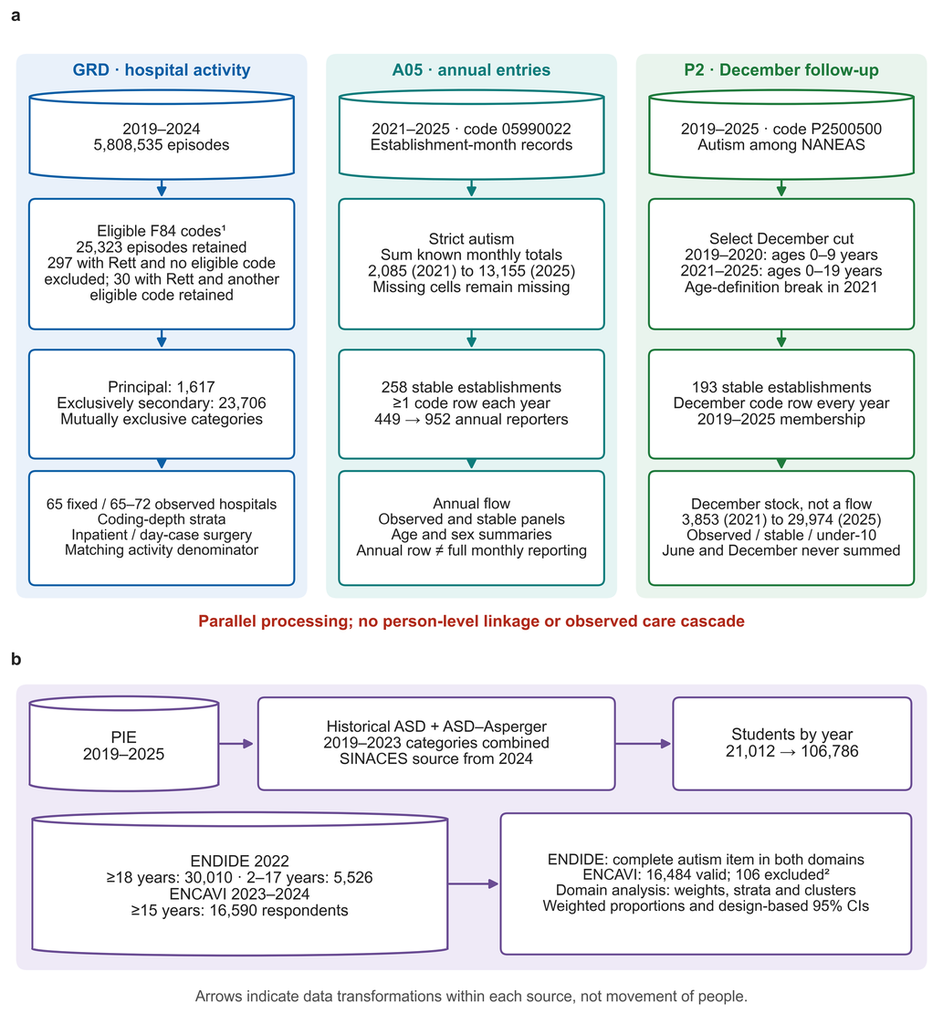

**Figure S1. Processing of the selected administrative records and population survey domains.** (a) Independent GRD, strict-autism A05 and December P2 analyses. (b) Educational harmonisation and survey-domain analysis. ¹Eligible ICD-10 codes are F84, F84.0, F84.1, F84.3, F84.4, F84.5, F84.8 and F84.9, in any diagnostic position. F84.2 never confers eligibility; another eligible code permits inclusion despite coexisting Rett. ²ENCAVI excludes 101 “do not know” and five nonresponses from the diagnosis domain. Stable membership requires the stated annual code-row presence and does not establish complete reporting or correct P2’s age expansion. NANEAS denotes children and adolescents with special health-care needs. Survey sample counts are unweighted; estimates and uncertainty use each survey’s design. Arrows show processing within sources, which remain unlinked. GRD=diagnosis-related groups; REM=Monthly Statistical Summaries; PIE=School Integration Programme; ENDIDE=National Disability and Dependency Survey; ENCAVI=National Quality of Life and Health Survey; SINACES=National Higher Education Quality Assurance System (these source names use Spanish acronyms). SINACES identifies the source report, not a new autism register. ASD=autism spectrum disorder; CI=confidence interval; ICD-10=International Classification of Diseases, tenth revision. A05 and P2 identify REM forms; NANEAS is expanded above. Abbreviations: A05=REM mental-health entry module; P2=REM child/adolescent special-health-needs follow-up module.

Plate files (175 mm, 300 dpi, revision 09): PNG · PDF